# Rapport_Diabète

tasnim

2025-10-09

# Mini-Projet (1) - Glycémie de patients diabétiques soumis à 2 régimes alimentaires différents

*Une nutritionniste souhaite comparer deux régimes différents, A et B, pour des patients diabétiques. Dans une population de patients diabétiques, elle a échantillonné aléatoirement 100 patients qui suivront le régime A (groupe 1) et 100 patients qui suivront le régime B (groupe 2). À la fin de l’expérience, qui dure 6 semaines, un test de glycémie à jeun est réalisé sur chaque patient.*

## *Description des données*

- *Quelle est la glycémie moyenne de chaque groupe ?*

```r
setwd("/Users/tasnim/Desktop/M1 InfoMed/Mini-projets(R)/(1)")
diabete <- read.table("diabete.txt")
summary(diabete)
```

```
##     groupe1          groupe2
##  Min.   :0.8491   Min.   :0.986
##  1st Qu.:1.0114   1st Qu.:1.064
##  Median :1.0633   Median :1.102
##  Mean   :1.0525   Mean   :1.098
##  3rd Qu.:1.0977   3rd Qu.:1.126
##  Max.   :1.2510   Max.   :1.230
```

- *Quel est l’écart-type de la distribution de la glycémie pour le régime A et pour le régime B ?*

```r
library(prettyR)
describe(diabete, num.desc=c("sd"))
```

```
## Description of diabete
```

```
##
##  Numeric
##           sd
## groupe1 0.08
## groupe2 0.05
```

Nous allons essayer de représenter graphiquement la distribution de chaque régime permettant de visualiser la médiane.

- *Pour ce faire, nous allons réaliser une boîte à moustache - boxplot :*

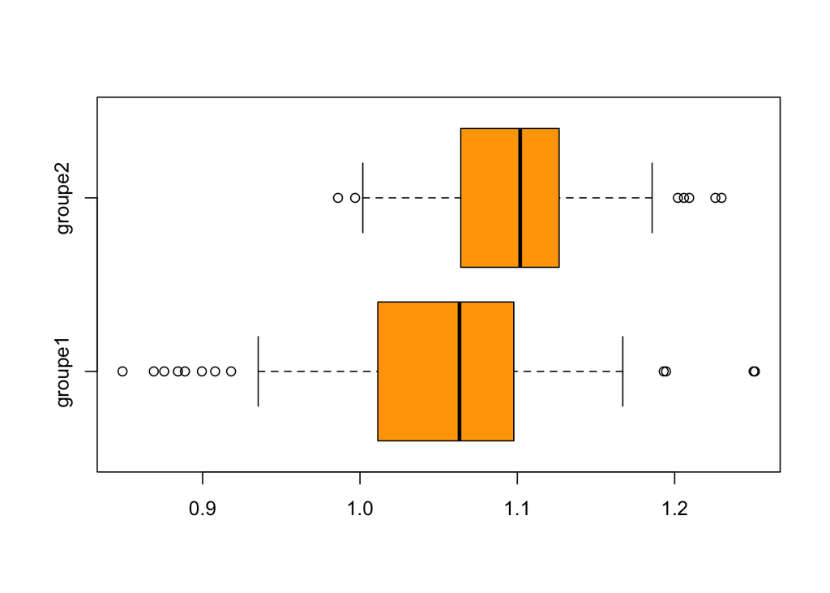

```r
boxplot (diabete, horizontal = TRUE, range = 1,col="orange")
```

## *Analyses statistiques*

- *Quelle est la différence moyenne de glycémie entre les deux régimes ?*

**Nous utilisons le test t Student pour comparer les moyennes de deux échantillons. Ces variables doivent suivre une loi normale. Pour vérifier si la distribution d’une variable est normale, nous pouvons réaliser un histogramme/qqplot. De plus le nombre de cas (n) doit être supèrieure à 30 et les variances égales (sinon test de Welch).** **Pour vérifier cela, nous avons tracé des graphiques pour vérifier la normalité. En utilisant la commande suivante :**

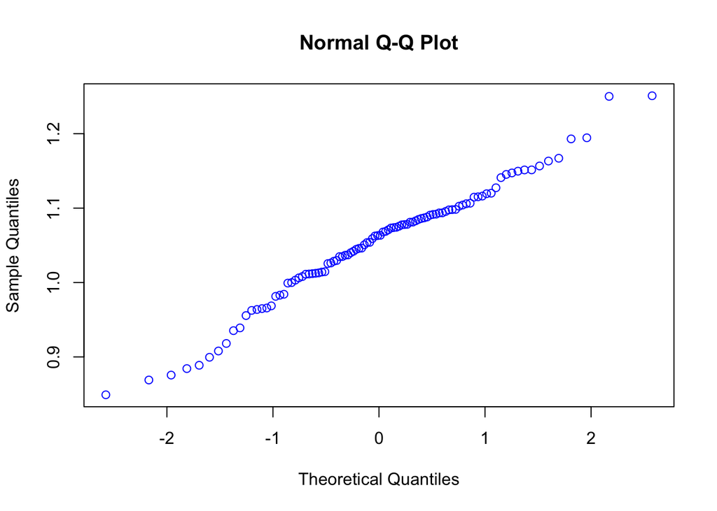

```r
qqnorm(diabete$groupe1,col="blue")
```

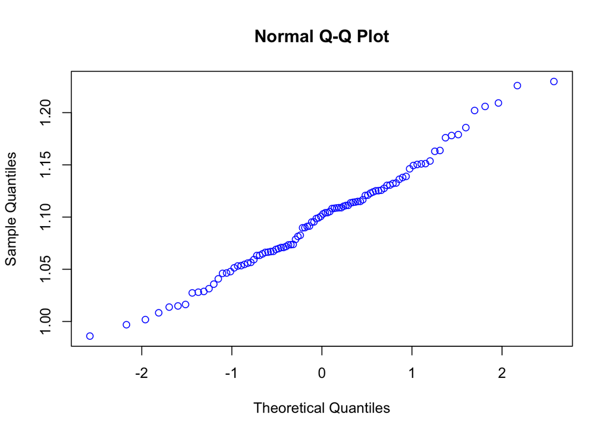

```r
qqnorm(diabete$groupe2,col="blue")
```

*Dès lors, nous pouvons effectuer le test t Student :*

```r
t.test(diabete$groupe1, diabete$groupe2,var.equal=TRUE)
```

```
##
##  Two Sample t-test
##
## data:  diabete$groupe1 and diabete$groupe2
## t = -4.8508, df = 198, p-value = 2.485e-06
## alternative hypothesis: true difference in means is not equal to 0
## 95 percent confidence interval:
##  -0.06411968 -0.02705408
## sample estimates:
## mean of x mean of y
##  1.052534  1.098121
```

Ainsi, nous rendons compte que les moyennes sont significativement différentes dans les 2 groupe. En effet, la ‘p-value’,ici, est inferieure à 2.485e-06.

## *Taille de l’échantillon*

*Nous allons essayer maintenant de faire tous ces tests sur un groupe de 10 patients choisis aléatoirement (groupe1b et groupe2b). Tout d’abord, il faut échantillonner aléatoiremment 10 patients de chaque groupe et pour ce faire nous utilisons ces commandes :*

```r
set.seed(1)
groupe1b <- sample(diabete$groupe1, 10)
groupe2b <- sample (diabete$groupe2, 10)
```

- *Glycémie moyenne de chaque groupe (groupe1b et groupe 2b) :*

```r
mean(groupe1b)
```

```
## [1] 1.050819
```

```r
mean(groupe2b)
```

```
## [1] 1.084869
```

- *Écart-type de la distribution de la glycémie pour le régime A (groupe1b) et pour le régime B (groupe2b) :*

```r
sd(groupe1b)
```

```
## [1] 0.08681866
```

```r
sd(groupe2b)
```

```
## [1] 0.04167296
```

- *Représentation de la distribution de la glycémie de chaque régime sous la forme d’un graphique permettant de visualiser la médiane et les quartiles :*

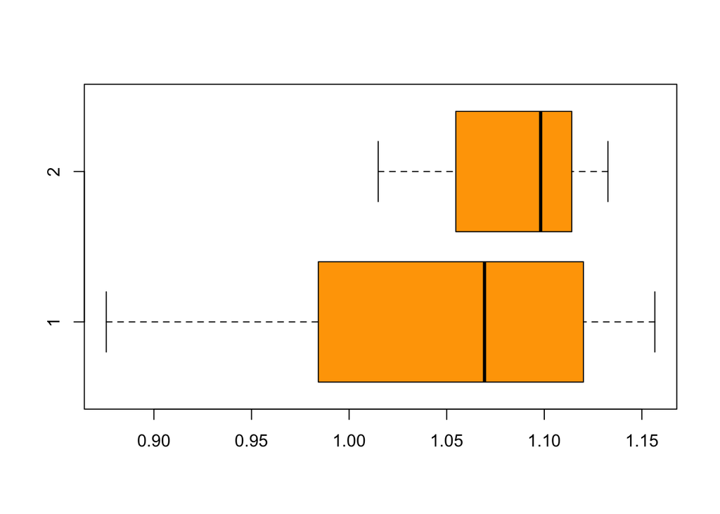

```r
boxplot (groupe1b,groupe2b, horizontal = TRUE, range = 1, col="orange")
```

- *Différence de moyennes de glycémie entre les 2 régimes :*

**Étant donné que nos échantillons (groupe1b et groupe2b) proviennent d’un échantillon suivant la normalité. Nous pouvons affirmer que nos groupes plus restreints suivent la loi normale. Mais nous allons quand même tester la normalité des échantillons :**

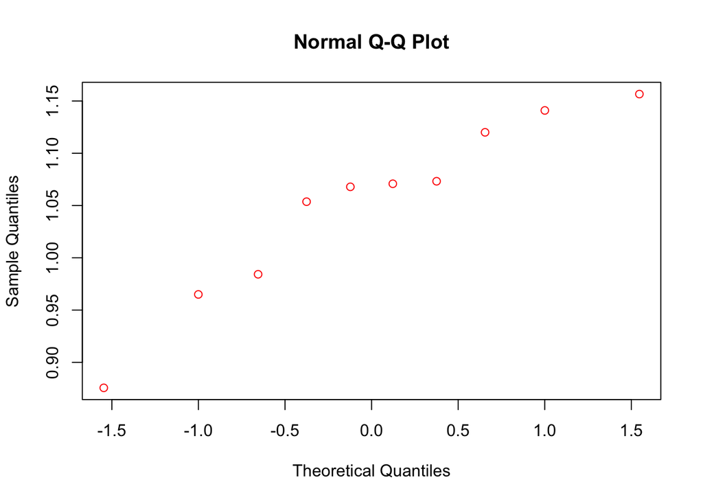

```r
qqnorm(groupe1b,col="red")
```

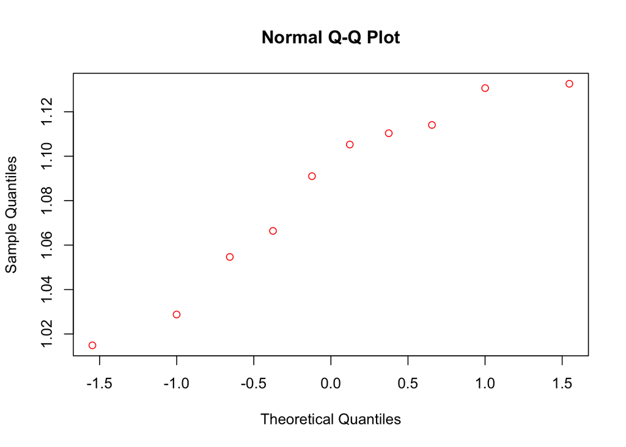

```r
qqnorm(groupe2b,col="red")
```

```r
t.test(groupe1b, groupe2b,var.equal=TRUE)
```

```
##
##  Two Sample t-test
##
## data:  groupe1b and groupe2b
## t = -1.1181, df = 18, p-value = 0.2782
## alternative hypothesis: true difference in means is not equal to 0
## 95 percent confidence interval:
##  -0.09803063  0.02992994
## sample estimates:
## mean of x mean of y
##  1.050819  1.084869
```

Nous remarquons que la ‘p-value’ = 0.2782. Cette valeur est supérieure à la ‘p-value’ précédente (<2.485e-06). Nous pouvons donc dire que cette différence n’est pas significative.

- *Quelle différence pouvons nous noter entre chaques résultats pour des groupes de 10 ou 100 patients ?*

La principale différence entre des groupes de 100 patients et de 10 patients concerne la fiabilité et la précision des résultats : les estimations issues d’un plus grand échantillon sont généralement plus stables, avec une variance plus faible et une marge d’erreur réduite. En effet, la p-value est signicative dans les groupes de 100 patients par comparaison aux groupes 1b et 2b (ayant seulement 10 patients). De ce fait, les groupes plus grands sont plus fiables pour des études statistiques. De plus, l’étendue de l’intervalle de confiance augmente si le nombre d’échantillons diminue.